[figure not shown]

# FIFA 19 ANALYSIS

### About the dataset

data.csv includes lastest edition FIFA 2019 players attributes like Age, Nationality, Overall, Potential, Club, Value, Wage, Preferred Foot, International Reputation, Weak Foot, Skill Moves, Work Rate, Position, Jersey Number, Joined, Loaned From, Contract Valid Until, Height, Weight, LS, ST, RS, LW, LF, CF, RF, RW, LAM, CAM, RAM, LM, LCM, CM, RCM, RM, LWB, LDM, CDM, RDM, RWB, LB, LCB, CB, RCB, RB, Crossing, Finishing, Heading, Accuracy, ShortPassing, Volleys, Dribbling, Curve, FKAccuracy, LongPassing, BallControl, Acceleration, SprintSpeed, Agility, Reactions, Balance, ShotPower, Jumping, Stamina, Strength, LongShots, Aggression, Interceptions, Positioning, Vision, Penalties, Composure, Marking, StandingTackle, SlidingTackle, GKDiving, GKHandling, GKKicking, GKPositioning, GKReflexes, and Release Clause. SOURCE: https://www.kaggle.com/karangadiya/fifa19

## Conclusions (Explanatory Analysis)

# Insights based on Univariant Analysis

Q1: how age frequency varies for professional soccer players?

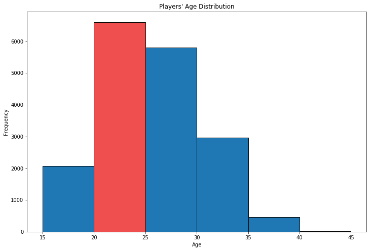

```python
plt.figure(figsize = (12 , 8))
bins = range(15, 46, 5)
n, bins, patches = plt.hist(data = df, x = 'Age', bins = bins, ec = 'black');
patches[1].set_color("#ef4f4f");
patches[1].set_edgecolor("black");
plt.title("Players' Age Distribution");
plt.xlabel("Age");
plt.ylabel("Frequency");
```

Q2 How do players' weights vary?

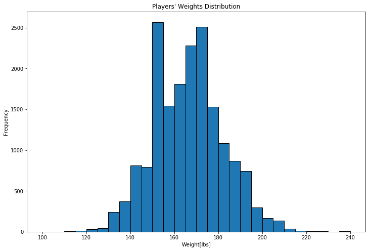

```python
plt.figure(figsize = (12 , 8));
bins = range(100, 245, 5)
n, bins, patches = plt.hist(data = df, x = 'Weight', bins = bins, ec = 'black');
plt.title("Players' Weights Distribution");
plt.xlabel("Weight[lbs]");
plt.ylabel("Frequency");
```

Well it seems like weights are normally distributed binomially around 150lbs and 175lbs

Q3 How do players' heights vary?

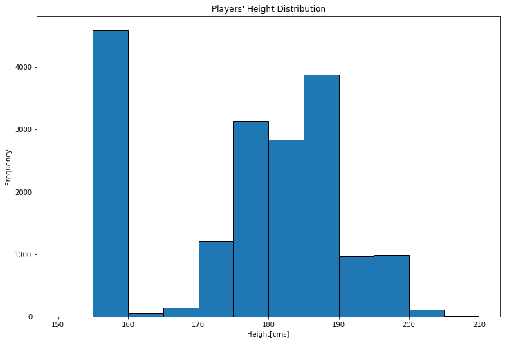

```python
plt.figure(figsize = (12 , 8))
bins = range(150, 215, 5)
plt.hist(data = df, x = 'Height', bins = bins, ec = 'black');
plt.title("Players' Height Distribution");
plt.xlabel("Height[cms]");
plt.ylabel("Frequency");
```

we got over 4,000 player with height around 160cms, on the other hand a lot of players have heights of 185 to 190 cms

Q4: Who are the best 10 players in FIFA 19?

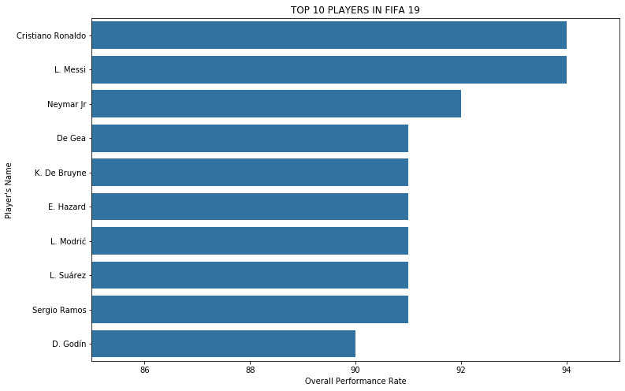

```python
plt.figure(figsize = (12 , 8))
top10players = df[['Name', 'Overall']].sort_values(['Overall'], ascending = False)[:10]
sb.barplot(data = top10players, y = 'Name', x = "Overall", color = sb.color_palette()[0])
plt.xlim(85, 95)
plt.title("TOP 10 PLAYERS IN FIFA 19")
plt.xlabel("Overall Performance Rate")
plt.ylabel("Player's Name");
```

Ronaldo and Messi come first, followed by Naymar Jr.!

Q5: Who are the most paid players?

[figure not shown]

```python
plt.figure(figsize = (12 , 8))
top10valued = top10players = df[['Name', 'Value']].sort_values(['Value'], ascending = False)[:10]
sb.barplot(data = top10valued, y = "Name", x = "Value", color= sb.color_palette()[0]);
plt.xlim(.5e8, 1.3e8)
xticks = np.arange(50e6, 150e6, 10e6)
xlabels = ['{:.0f}'.format(x) for x in xticks]
plt.xticks(xticks, xlabels)
plt.title("TOP 10 PAIED PLAYERS IN FIFA 19");
plt.xlabel("Overall Performance Rate");
plt.ylabel("Player's Name");
plt.grid()
```

Unsurprisingly, Naymar gets the highest amount,then Messi and De Bruyne

Q6: Which are the best performing clubs?

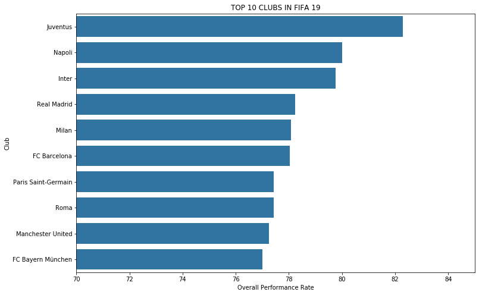

```python
plt.figure(figsize = (12 , 8))
top10clubs = df[['Club', "Overall"]].groupby("Club").mean().sort_values('Overall',ascending = False)[:10].reset_index()
sb.barplot(data = top10clubs, y = 'Club',x = 'Overall', color= sb.color_palette()[0])
plt.xlim(70, 85)
plt.title("TOP 10 CLUBS IN FIFA 19")
plt.xlabel("Overall Performance Rate")
plt.ylabel("Club");
```

5 Italian clubs are in the top 10, Juventus comes first then Napoli and Inter

# Insights based on Bivariant Analysis

Q7: Which are the main abilities that affect on the overall performance?

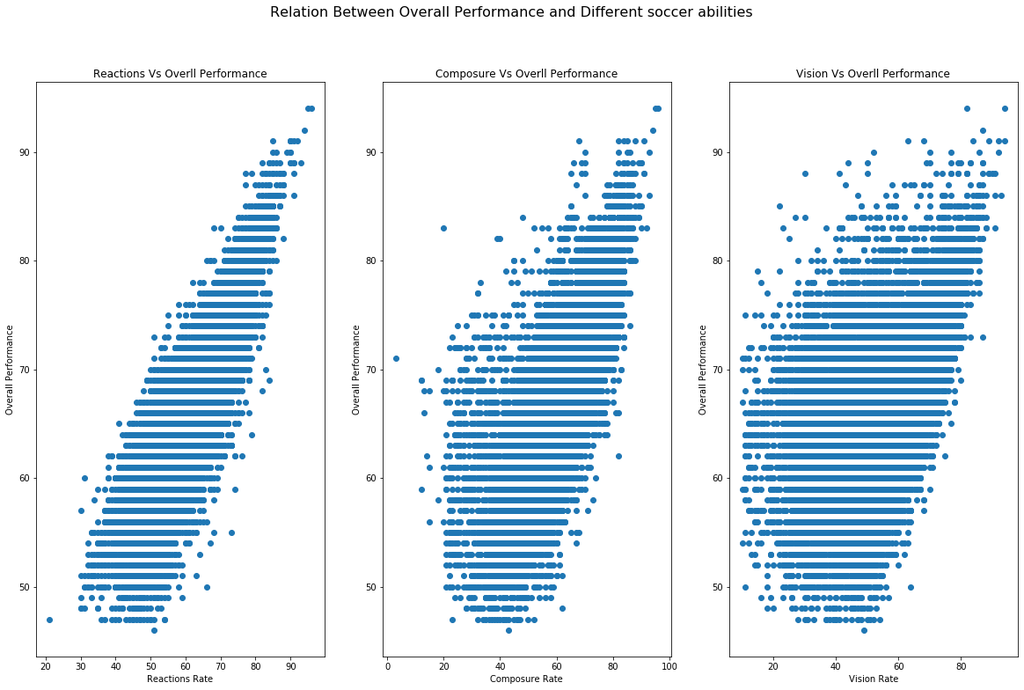

```python
plt.figure(figsize= (20, 12))
plt.suptitle("Relation Between Overall Performance and Different soccer abilities", fontsize = 16)
plt.subplot(1,3,1)
plt.scatter(data = df, x = 'Reactions', y = 'Overall')
plt.title("Reactions Vs Overll Performance")
plt.xlabel("Reactions Rate")
plt.ylabel("Overall Performance")
#--
plt.subplot(1,3,2)
plt.scatter(data = df, x = 'Composure', y = 'Overall')
plt.title("Composure Vs Overll Performance")
plt.xlabel("Composure Rate")
plt.ylabel("Overall Performance")
#--
plt.subplot(1,3,3)
plt.scatter(data = df, x = 'Vision', y = 'Overall')
plt.title("Vision Vs Overll Performance")
plt.xlabel("Vision Rate")
plt.ylabel("Overall Performance");
```

Reactions, Composure, Vision

Q8: Among the top 10 performing clubs, which clubs pay the higher?

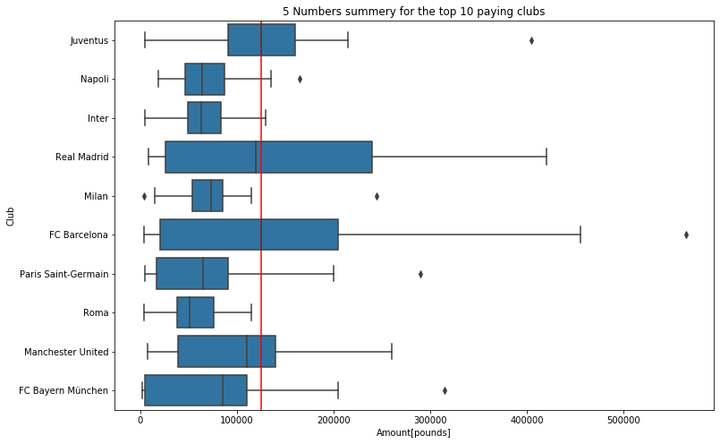

```python
plt.figure(figsize = (12, 8))
sb.boxplot(data = subDF, y = 'Club', x= 'Wage', order= top10clubs.Club, color = sb.color_palette()[0]);
jev_med = subDF[subDF.Club == "Juventus"].Wage.median()
plt.axvline(x = jev_med, color = 'red');
plt.title("5 Numbers summery for the top 10 paying clubs");
plt.ylabel("Club");
plt.xlabel("Amount[pounds]");
```

Well Juventus comes first, then Barcelona and Real Madrid and Roma comes the last!

# Insights Based on Multivariant Analysis

Q10: How overall performance differs among positions with respect to preferred foot?

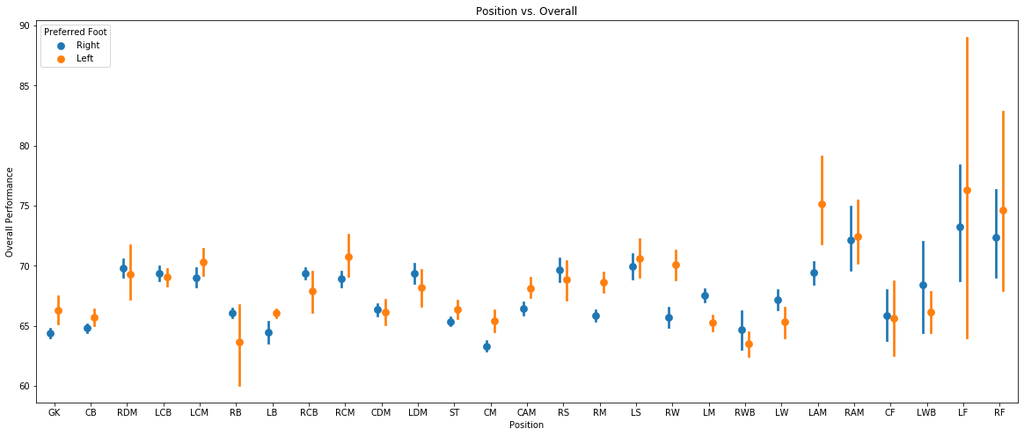

```python
plt.figure(figsize =(20, 8))
sb.pointplot(data = df, x = "Position", y = 'Overall', hue = "Preferred Foot", dodge = .2, linestyles = "");
plt.title("Position vs. Overall");
plt.xlabel("Position");
plt.ylabel("Overall Performance");
```

Left legged players at Left Forward positions have the higher performance values!

Q11: How shooting power changes with respect to position, and does Footedness affect?

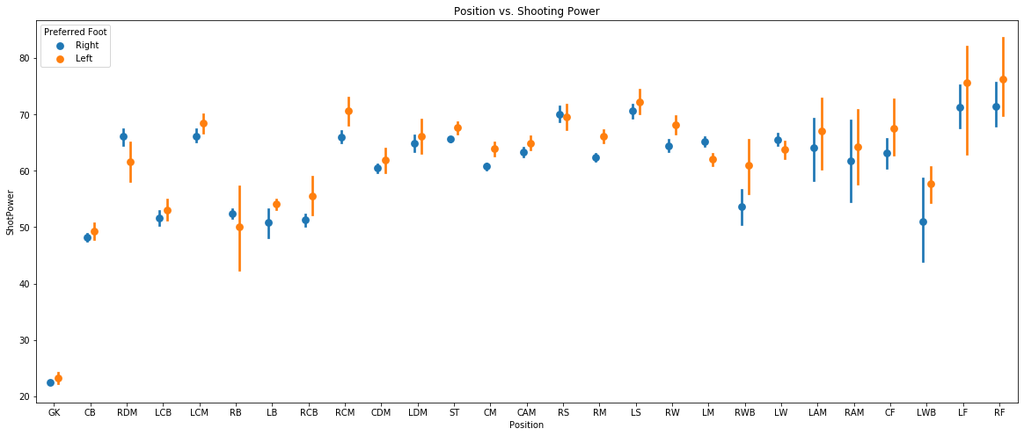

```python
plt.figure(figsize =(20, 8))
sb.pointplot(data = df, x = "Position", y = 'ShotPower', hue = "Preferred Foot", dodge = .2, linestyles = "")
plt.title("Position vs. Shooting Power");
```

Players that play Forward have high shooting power then whose in the Middle but footedness doesn't affect that much!

Q12: Does Overall Performance, International Reputation, and Skill Moves correlate as we assume by intuition?

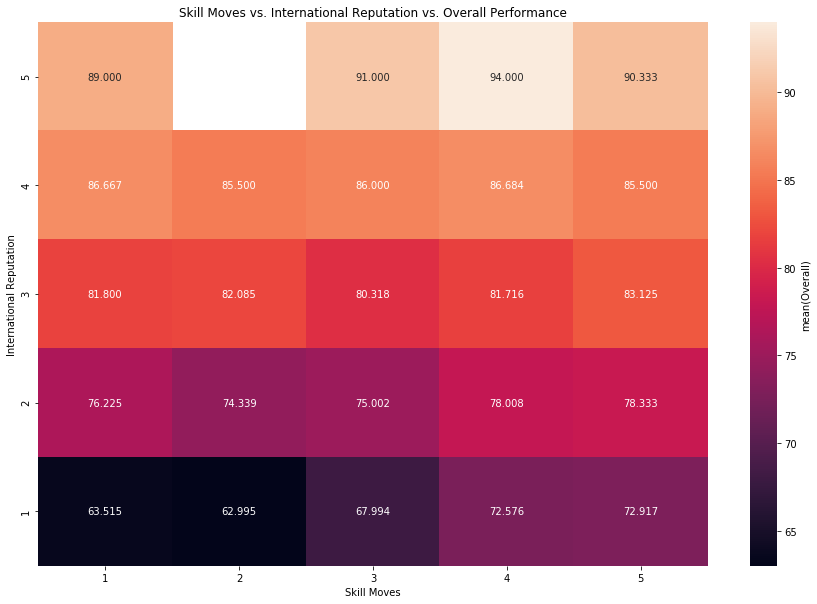

```python
plt.figure(figsize = (15, 10))
cat_means = df.groupby(['Skill Moves', 'International Reputation']).mean()['Overall']
cat_means = cat_means.reset_index(name = 'Overall')
cat_means = cat_means.pivot(index = 'International Reputation', columns = 'Skill Moves',
                            values = 'Overall')
sb.heatmap(cat_means, annot = True, fmt = '.3f',
           cbar_kws = {'label' : 'mean(Overall)'});
plt.title("Skill Moves vs. International Reputation vs. Overall Performance");
```

Yes they strongly are!

Q13: Do physical characteristics affect much on the player's Stamina??

[figure not shown]

```python
plt.figure(figsize = (15, 10))
plt.scatter(data = df, x = 'Weight', y = 'Height', c = 'Stamina')
plt.colorbar(label = 'Stamina Rate');
plt.title("Weight vs. Height vs. Stamina")
plt.xlabel("Height[cms]")
plt.ylabel("Weights[lbs]");
```

We could Notice that low stamina rates are observed at high weights and heights!

# That's All, Thank UOY! :)